# Palaepaphos mudbrick analysis

Uine Kailamäki

### pXRF

From literature we can identify three rough classes of elements that could be used to analyze mudbricks from pXRF results:

Good: Rb, Sr, Y, Zr, Nb, Th, Pb, Cu, Zn, Fe  
Neutral: V, Cr, Co, Ni, Ca, Ti  
Bad: Na, P, Ba (+ Ca, Al)

```r
MB_table <- matrix(c("LA54/4",  "30 cm x 18 cm", "Top row - weathered",
                  "LA54/4", "25 cm x 18 cm",    "Mid 4th row from the top",
                  "LA54/4", "35 cm x 18 cm (est.)", "B. 8th row from the top",
                  "LA54/4", "45 cm x 18 cm",    "9th row from the top",
                  "LA54/4", "46 cm x 16 cm",    "6th row from the top",
                  "LA59/2", "45 cm x 15 cm (est.)", "Top row - weathered",
                  "LA59/2", "45 cm x 15 cm (est.)", "3rd row from the top",
                  "LA59/2", "33 cm x 15 cm (est.)", "5th row below stones",
                  "LA59/2", "44 cm x 13 cm",    "9th row of the top",
                  "LA59/2", "40 cm x 20 cm",    "B. below disturbance under the marl",
                  "LA54/7", "14 cm x 15 cm (est.)", "(no additional info)"),
                  ncol=3, byrow=TRUE)
colnames(MB_table) <- c("Context", "Size", "Row")
rownames(MB_table) <- c("PP-9", "PP-10", "PP-11", "PP-12", "PP-13", "PP-14", "PP-15", "PP-16", "PP-17", "PP-18", "PP-19")
MB_table <- as.table(MB_table)

library(knitr)
kable(MB_table)
```

|  | Context | Size | Row |
| --- | --- | --- | --- |
| PP-9 | LA54/4 | 30 cm x 18 cm | Top row - weathered |
| PP-10 | LA54/4 | 25 cm x 18 cm | Mid 4th row from the top |
| PP-11 | LA54/4 | 35 cm x 18 cm (est.) | B. 8th row from the top |
| PP-12 | LA54/4 | 45 cm x 18 cm | 9th row from the top |
| PP-13 | LA54/4 | 46 cm x 16 cm | 6th row from the top |
| PP-14 | LA59/2 | 45 cm x 15 cm (est.) | Top row - weathered |
| PP-15 | LA59/2 | 45 cm x 15 cm (est.) | 3rd row from the top |
| PP-16 | LA59/2 | 33 cm x 15 cm (est.) | 5th row below stones |
| PP-17 | LA59/2 | 44 cm x 13 cm | 9th row of the top |
| PP-18 | LA59/2 | 40 cm x 20 cm | B. below disturbance under the marl |
| PP-19 | LA54/7 | 14 cm x 15 cm (est.) | (no additional info) |

#### Data preparation

```r
# Libraries
library(openxlsx);
library(dplyr);
```

```r
library(ggfortify); # PCA autoplots
library(FactoMineR); # Fast PCA graphs
library(plot3D); # 3D plots
library(dendextend); # Dendrograms
# Read the raw data
pxrf <- read.xlsx("data/pxrf_PP.xlsx", sep=";")

# Remove any rows containing words 'ERROR' or 'TEST'
pxrf <- filter(pxrf, !grepl('TEST', Sample))
pxrf <- filter(pxrf, !grepl('ERROR', Sample))

# Remove unused columns
pxrf <- pxrf %>%
        select(-Site) %>%
        select(-'Other;name') %>%
        select(-'File;#') %>%
        select(-DateTime) %>%
        select(-Application) %>%
        select(-Method) %>%
        select(-ElapsedTime) %>%
        select(-'Cal;Check')

# Coercing "< LOD" -results to NA:s
pxrf[4:93] <- pxrf[4:93] %>% mutate_if(is.character,as.numeric)
```

[output not shown]

[output cut: 8 more lines]

[output not shown]

```r
# Averaging results by "Sample", "Area" and "Type" columns
pxrf_averaged <- aggregate(pxrf, by = list(pxrf$Sample, pxrf$Area, pxrf$Type), FUN = mean)
```

[output not shown]

[output cut: 112 more lines]

[output not shown]

```r
# Removing old (now empty) columns
pxrf_averaged <- pxrf_averaged %>% select(-Sample)
pxrf_averaged <- pxrf_averaged %>% select(-Area)
pxrf_averaged <- pxrf_averaged %>% select(-Type)

# Assigning sample names as new row names
rownames(pxrf_averaged) <- pxrf_averaged$Group.1
pxrf_averaged <- pxrf_averaged %>% select(-Group.1)

# Renaming the other two newly created groups back to "Type" and "Area"
names(pxrf_averaged)[names(pxrf_averaged) == "Group.2"] <- "Area"
names(pxrf_averaged)[names(pxrf_averaged) == "Group.3"] <- "Type"

# Removing error columns from the scaled analysis data set
pxrf_scaled <- pxrf_averaged %>% select(-ends_with("Err"))

# Scaling the data with standard z-score method
pxrf_scaled[3:47] <- scale(pxrf_scaled[3:47])

# Removing columns that only contain NA values
all_na <- function(x) any(!is.na(x))
pxrf_all <- pxrf_scaled %>% select_if(all_na)
```

**pxrf_averaged**: All averaged data including averaged errors (Uine’s note: for later use) **pxrf_errors**: Averaged data including averaged errors, missing and dubious elements emitted

```r
pxrf_errors <- pxrf_averaged %>% select_if(all_na)
pxrf_errors <- pxrf_errors %>%
        select(-Al2O3) %>%
        select(-'Al2O3;Err') %>%
        select(-CaO) %>%
        select(-'CaO;Err') %>%
        select(-SiO2) %>%
        select(-'SiO2;Err') %>%
        select(-Cl) %>%
        select(-'Cl;Err') %>%
        select(-K2O) %>%
        select(-'K2O;Err') %>%
        select(-Ni) %>%
        select(-'Ni;Err') %>%
        select(-P2O5) %>%
        select(-'P2O5;Err') %>%
        select(-S) %>%
        select(-'S;Err') %>%
        select(-V) %>%
        select(-'V;Err') %>%
        select(-As) %>%
        select(-'As;Err') %>%
        select(-Rh) %>%
        select(-'Rh;Err') %>%
        select(-Ag) %>%
          select(-'Cr;Err') %>%
          select(-'Co;Err') %>%
          select(-'Se;Err') %>%
          select(-Nb) %>%
          select(-'Nb;Err') %>%
          select(-'Mo;Err') %>%
          select(-'Pd;Err') %>%
          select(-'Cd;Err') %>%
          select(-'Sn;Err') %>%
          select(-'Sb;Err') %>%
          select(-'Ba;Err') %>%
          select(-'La;Err') %>%
          select(-'Ag;Err') %>%
          select(-'Ce;Err') %>%
          select(-'Hf;Err') %>%
          select(-'Ta;Err') %>%
          select(-'W;Err') %>%
          select(-'Pt;Err') %>%
          select(-'Au;Err') %>%
          select(-'Hg;Err') %>%
          select(-'Tl;Err') %>%
          select(-Pb) %>%
          select(-'Pb;Err') %>%
          select(-'Bi;Err') %>%
          select(-'Th;Err') %>%
          select(-'U;Err')

pxrf_errors[3:22] <- (pxrf_errors[3:22] * 1000)
pxrf_errors[3:22] <- round(pxrf_errors[3:22], digits = 1)

kable(pxrf_errors[3:22])
```

|  | MgO | MgO;Err | Ti | Ti;Err | Mn | Mn;Err | Fe | Fe;Err | Cu | Cu;Err | Zn | Zn;Err | Rb | Rb;Err | Sr | Sr;Err | Y | Y;Err | Zr | Zr;Err |
| --- | --- | --- | --- | --- | --- | --- | --- | --- | --- | --- | --- | --- | --- | --- | --- | --- | --- | --- | --- | --- |
| PP-10 | 3703.8 | 922.4 | 195.4 | 3.9 | 39.0 | 2.6 | 2213.5 | 11.9 | 11.3 | 0.7 | 3.7 | 0.4 | 1.5 | 0.4 | 39.0 | 0.6 | 1.4 | 0.5 | 8.1 | 0.4 |
| PP-11 | 4009.8 | 1062.1 | 229.5 | 4.3 | 38.5 | 2.8 | 2386.6 | 13.0 | 5.5 | 0.5 | 2.5 | 0.3 | 1.6 | 0.3 | 29.0 | 0.5 | 1.1 | 0.4 | 7.5 | 0.3 |
| PP-12 | 2918.5 | 719.6 | 126.3 | 3.2 | 17.8 | 1.7 | 1005.8 | 7.3 | 5.6 | 0.6 | 3.2 | 0.5 | 1.8 | 0.5 | 28.3 | 0.8 | NA | 0.7 | 8.9 | 0.5 |
| PP-13 | 4547.7 | 1093.6 | 192.8 | 4.0 | 38.9 | 2.6 | 2131.2 | 12.0 | 11.3 | 0.7 | 5.0 | 0.4 | 2.1 | 0.3 | 48.4 | 0.7 | 1.5 | 0.5 | 10.2 | 0.4 |
| PP-9 | 4369.6 | 1200.2 | 191.5 | 3.9 | 41.8 | 2.7 | 2448.1 | 12.7 | 7.7 | 0.6 | 3.9 | 0.4 | 2.1 | 0.3 | 46.8 | 0.6 | 1.5 | 0.5 | 11.8 | 0.4 |
| PP-19 | 4164.6 | 853.1 | 96.9 | 3.3 | 11.9 | 1.7 | 961.7 | 7.8 | 4.5 | 0.6 | 1.7 | 0.4 | NA | 0.4 | 31.8 | 0.7 | NA | 0.6 | 6.1 | 0.5 |
| PP-14 | 4430.4 | 1051.3 | 218.8 | 4.2 | 33.5 | 2.6 | 2224.1 | 12.5 | 6.7 | 0.6 | 2.4 | 0.3 | 1.7 | 0.3 | 35.1 | 0.6 | 1.4 | 0.5 | 8.8 | 0.4 |
| PP-15 | 4088.3 | 1177.5 | 182.1 | 3.7 | 27.1 | 2.3 | 1878.0 | 11.1 | 7.3 | 0.7 | 3.2 | 0.5 | 1.9 | 0.4 | 35.3 | 0.7 | 1.6 | 0.6 | 9.3 | 0.5 |
| PP-16 | 5124.8 | 1222.8 | 192.2 | 3.9 | 39.8 | 2.6 | 2300.3 | 12.5 | 9.7 | 0.7 | 3.9 | 0.4 | 1.7 | 0.4 | 37.7 | 0.6 | 1.7 | 0.5 | 8.7 | 0.4 |
| PP-17 | 3273.7 | 960.4 | 170.9 | 3.6 | 28.6 | 2.2 | 1762.4 | 10.1 | 6.3 | 0.6 | 3.4 | 0.4 | 1.9 | 0.4 | 28.8 | 0.6 | 1.3 | 0.6 | 8.7 | 0.4 |
| PP-18 | 3359.0 | 969.9 | 161.8 | 4.0 | 20.8 | 2.2 | 1491.6 | 10.5 | 4.7 | 0.6 | 1.9 | 0.3 | 1.2 | 0.3 | 17.9 | 0.5 | 0.9 | 0.5 | 5.4 | 0.4 |
| PP-1 | 3378.9 | 877.4 | 136.8 | 3.4 | 24.7 | 2.0 | 1295.9 | 8.8 | 5.7 | 0.6 | 3.4 | 0.5 | 2.0 | 0.4 | 33.9 | 0.7 | 1.4 | 0.6 | 9.2 | 0.5 |
| PP-2 | 4717.6 | 1441.6 | 155.8 | 3.4 | 44.0 | 2.7 | 2338.2 | 12.1 | 5.9 | 0.5 | 3.2 | 0.3 | 2.1 | 0.3 | 34.0 | 0.5 | 1.7 | 0.4 | 9.6 | 0.4 |
| PP-3 | 3290.0 | 816.9 | 143.1 | 3.3 | 31.7 | 2.2 | 1677.0 | 9.8 | 6.6 | 0.6 | 4.5 | 0.5 | 2.1 | 0.4 | 40.0 | 0.7 | 1.6 | 0.6 | 9.7 | 0.5 |
| PP-4 | 3165.8 | 1123.0 | 181.1 | 4.2 | 42.7 | 2.7 | 2308.1 | 12.1 | 5.6 | 0.5 | 3.8 | 0.4 | 2.1 | 0.3 | 35.9 | 0.6 | 1.6 | 0.5 | 8.7 | 0.4 |
| PP-5 | 4450.8 | 1561.7 | 155.4 | 3.4 | 47.0 | 2.8 | 2435.1 | 12.4 | 5.3 | 0.5 | 3.7 | 0.3 | 2.3 | 0.3 | 40.9 | 0.6 | 1.8 | 0.4 | 10.4 | 0.4 |
| PP-6 | 3694.8 | 1296.6 | 203.2 | 3.6 | 52.2 | 2.8 | 2555.2 | 12.4 | 5.8 | 0.5 | 3.1 | 0.4 | 2.9 | 0.3 | 24.0 | 0.5 | 2.2 | 0.5 | 9.5 | 0.4 |
| PP-7 | 4780.3 | 1956.9 | 237.1 | 3.9 | 56.3 | 3.1 | 3061.0 | 13.8 | 5.7 | 0.5 | 4.0 | 0.4 | 3.6 | 0.3 | 31.0 | 0.5 | 2.6 | 0.5 | 12.2 | 0.4 |
| PP-8 | 4738.8 | 1249.7 | 175.4 | 3.7 | 36.3 | 2.6 | 1912.4 | 11.3 | 6.0 | 0.6 | 3.1 | 0.4 | 2.2 | 0.3 | 28.4 | 0.5 | 2.1 | 0.5 | 7.8 | 0.4 |

**pxrf_all**: All “possible” elements (the numbers below are the amount of NA values)

```r
colSums(is.na(pxrf_all))
```

```
##  Area  Type   MgO Al2O3  SiO2  P2O5     S    Cl   K2O   CaO    Ti     V    Mn
##     0     0     0     0     0     1     1     0     2     0     0     7     0
##    Fe    Ni    Cu    Zn    As    Rb    Sr     Y    Zr    Rh    Ag
##     0     0     0     0    14     1     0     2     0    17    15
```

**pxrf_final**: Final analysis data set with only the selected elements

```r
# Dropping the dubious elements and elements with too many NA values
pxrf_final <- pxrf_all %>%
        select(-Al2O3) %>%
        select(-CaO) %>%
        select(-SiO2) %>%
        select(-Cl) %>%
        select(-K2O) %>%
        select(-Ni) %>%
        select(-P2O5) %>%
        select(-S) %>%
        select(-V) %>%
        select(-As) %>%
        select(-Rh) %>%
        select(-Ag) %>%
        select(-MgO) %>%
        select(-Cu)

# Transforming remaining NA values to zeros for analysis
pxrf_final[is.na(pxrf_final)] <- 0

# Final analysis data set
colnames(pxrf_final)
```

```
##  [1] "Area" "Type" "Ti"   "Mn"   "Fe"   "Zn"   "Rb"   "Sr"   "Y"    "Zr"
```

**pxrf_MB**: Final analysis data set for MUDBRICK samples only (= no soil)

```r
pxrf_MB <- pxrf_final[c(1:11), ]
```

#### pXRF: K means cluster analysis

Only mudbrick samples, K-means cluster analysis with 5 possible clusters

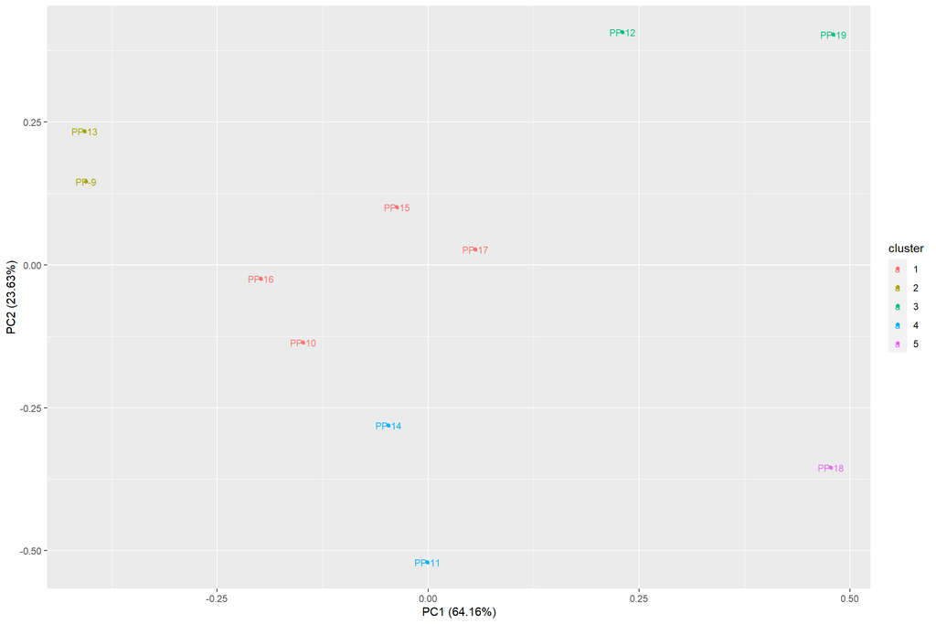

```r
# PC autoplot with K-means clusters
set.seed(1)
autoplot(kmeans(pxrf_MB[3:10], 5), data = pxrf_MB, label = TRUE, label.size = 3)
```

#### pXRF: PCA

**PCA with only mudbrick samples**:

```r
# Elements
colnames(pxrf_MB[3:10])
```

```
## [1] "Ti" "Mn" "Fe" "Zn" "Rb" "Sr" "Y"  "Zr"
```

```r
# PCA analysis
pca_1 <- prcomp(pxrf_MB[3:10])
summary(pca_1)
```

```
## Importance of components:
##                           PC1    PC2     PC3     PC4     PC5    PC6     PC7
## Standard deviation     2.1953 1.3321 0.64002 0.51919 0.36557 0.2293 0.21338
## Proportion of Variance 0.6416 0.2363 0.05454 0.03589 0.01779 0.0070 0.00606
## Cumulative Proportion  0.6416 0.8779 0.93241 0.96830 0.98609 0.9931 0.99915
##                            PC8
## Standard deviation     0.07974
## Proportion of Variance 0.00085
## Cumulative Proportion  1.00000
```

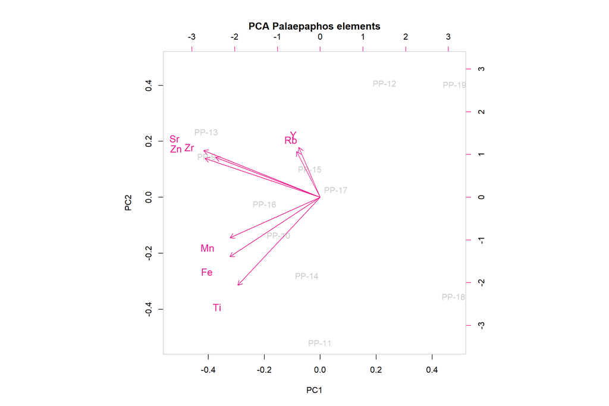

```r
# PCA plots
biplot(pca_1, choices = 1:2, cex = c(1, 1.2), col = c("grey80", "deeppink2"), main = "PCA Palaepaphos elements")
```

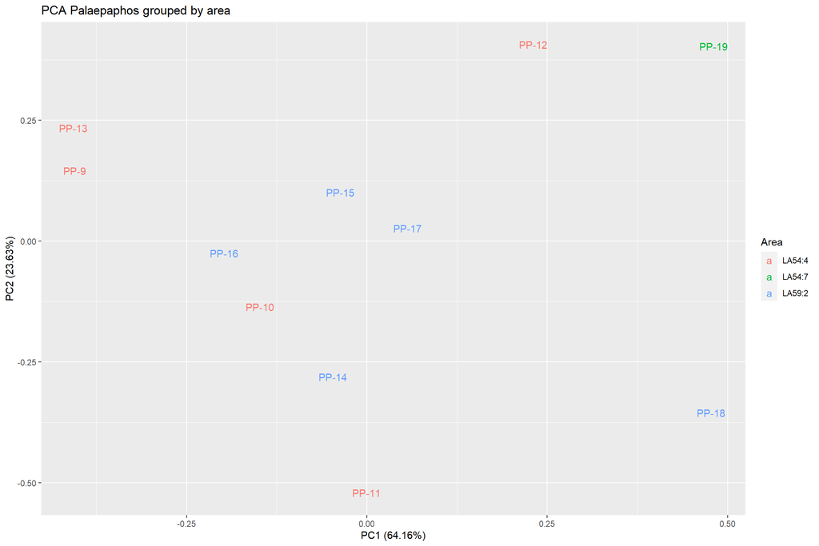

```r
autoplot(pca_1, data=pxrf_MB, colour='Area', shape = FALSE, label = TRUE,  main = "PCA Palaepaphos grouped by area")
```

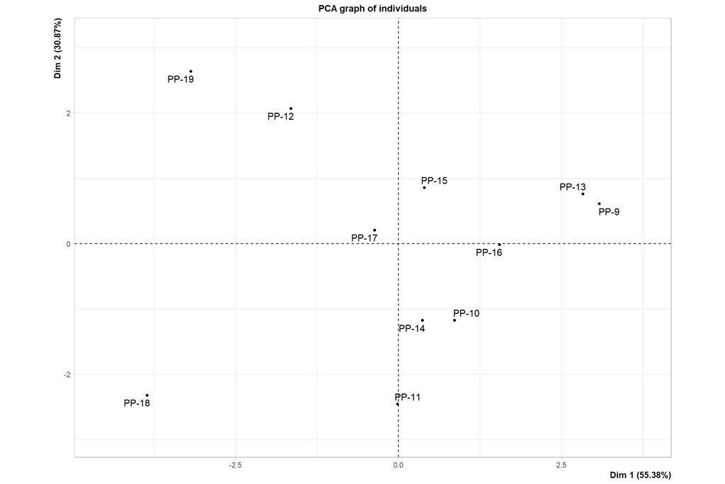

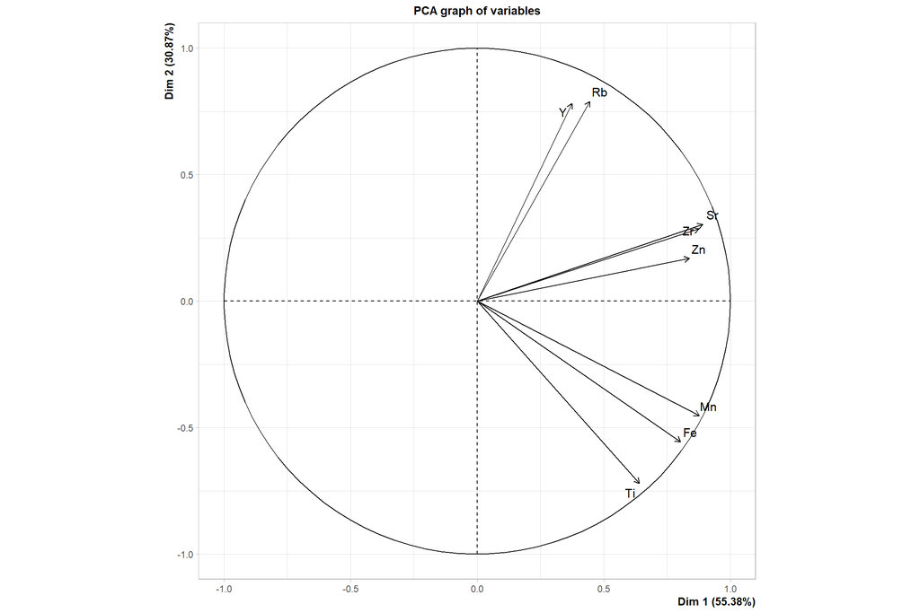

```
## **Results for the Principal Component Analysis (PCA)**
## The analysis was performed on 11 individuals, described by 8 variables
## *The results are available in the following objects:
##
##    name               description
## 1  "$eig"             "eigenvalues"
## 2  "$var"             "results for the variables"
## 3  "$var$coord"       "coord. for the variables"
## 4  "$var$cor"         "correlations variables - dimensions"
## 5  "$var$cos2"        "cos2 for the variables"
## 6  "$var$contrib"     "contributions of the variables"
## 7  "$ind"             "results for the individuals"
## 8  "$ind$coord"       "coord. for the individuals"
## 9  "$ind$cos2"        "cos2 for the individuals"
## 10 "$ind$contrib"     "contributions of the individuals"
## 11 "$call"            "summary statistics"
## 12 "$call$centre"     "mean of the variables"
## 13 "$call$ecart.type" "standard error of the variables"
## 14 "$call$row.w"      "weights for the individuals"
## 15 "$call$col.w"      "weights for the variables"
```

```r
PCA(pxrf_MB[3:10])
```

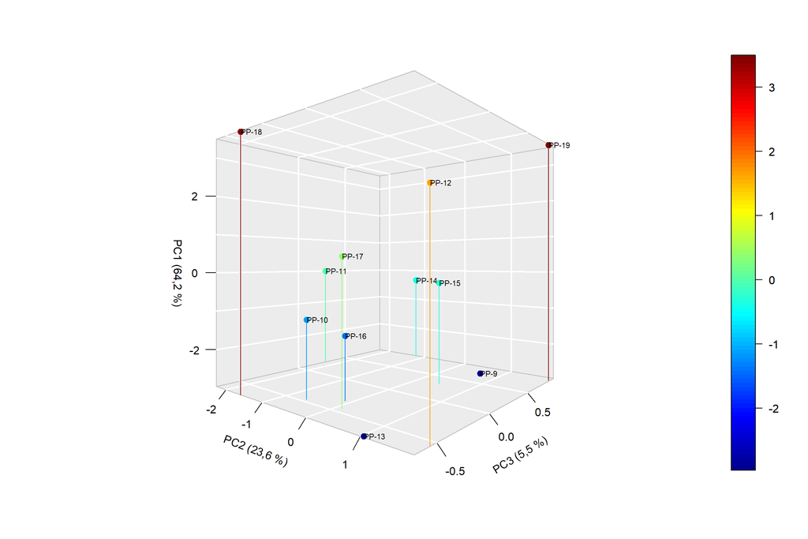

```r
#3D plot
scores = as.data.frame(pca_1$x)
scatter3D(scores$PC2, scores$PC3, scores$PC1,
          xlab = "PC2 (23,6 %)", ylab = "PC3 (5,5 %)", zlab="PC1 (64,2 %)",
          phi = 0, bty = "g",  type = "h",
          ticktype = "detailed", pch = 19, cex = 1.2)
text3D(scores$PC2, scores$PC3, scores$PC1, labels = rownames(scores),
          add = TRUE, colkey = FALSE, cex = 0.7)
```

**PCA with soil samples**:

```r
# Elements
colnames(pxrf_final[3:10])
```

```
## [1] "Ti" "Mn" "Fe" "Zn" "Rb" "Sr" "Y"  "Zr"
```

```r
# PCA analysis
pca_3 <- prcomp(pxrf_final[3:10])
summary(pca_3)
```

```
## Importance of components:
##                           PC1    PC2    PC3     PC4     PC5     PC6     PC7
## Standard deviation     2.0914 1.2316 1.1079 0.50947 0.47796 0.38969 0.25389
## Proportion of Variance 0.5584 0.1936 0.1567 0.03314 0.02916 0.01939 0.00823
## Cumulative Proportion  0.5584 0.7520 0.9087 0.94180 0.97096 0.99035 0.99858
##                            PC8
## Standard deviation     0.10547
## Proportion of Variance 0.00142
## Cumulative Proportion  1.00000
```

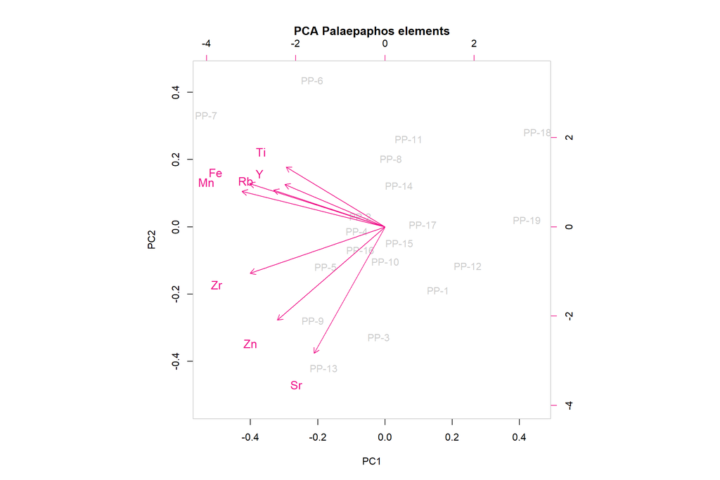

```r
# PCA plots
biplot(pca_3, choices = 1:2, cex = c(1, 1.2), col = c("grey80", "deeppink2"), main = "PCA Palaepaphos elements")
```

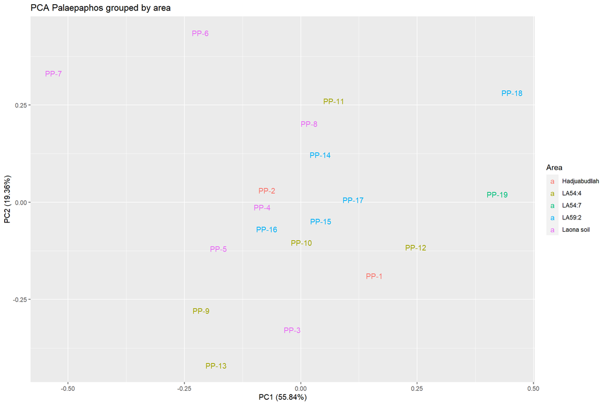

```r
autoplot(pca_3, data=pxrf_final, colour='Area', shape = FALSE, label = TRUE,  main = "PCA Palaepaphos grouped by area")
```

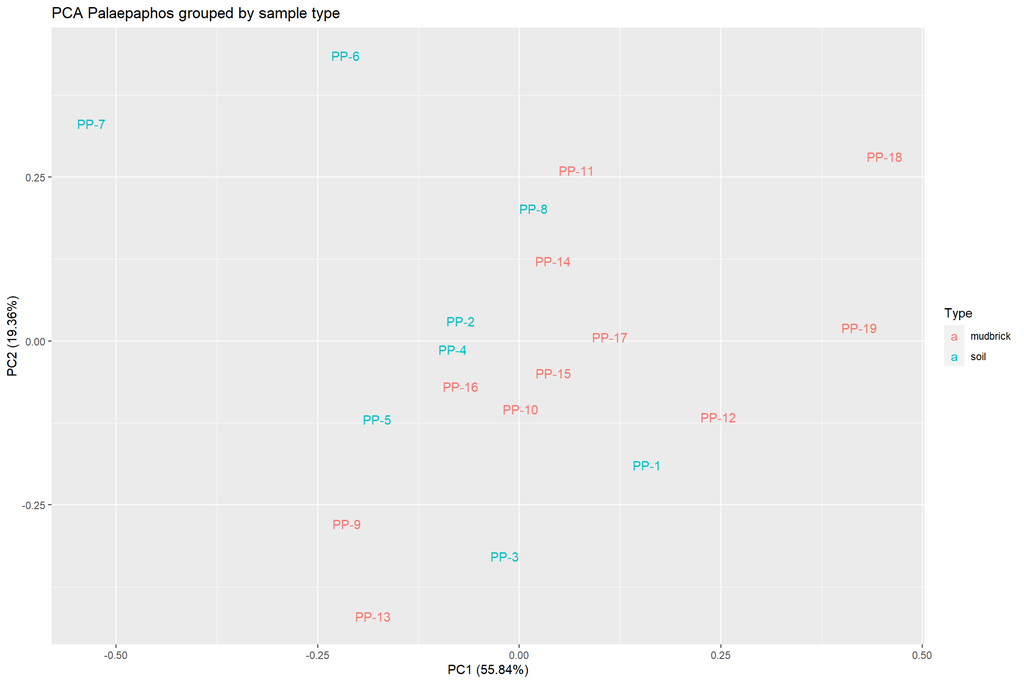

```r
autoplot(pca_3, data=pxrf_final, colour='Type', shape = FALSE, label = TRUE,  main = "PCA Palaepaphos grouped by sample type")
```

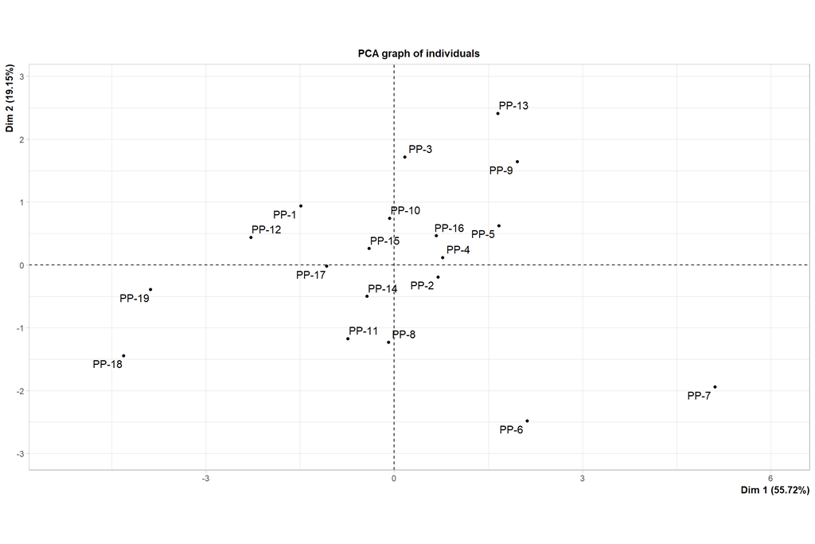

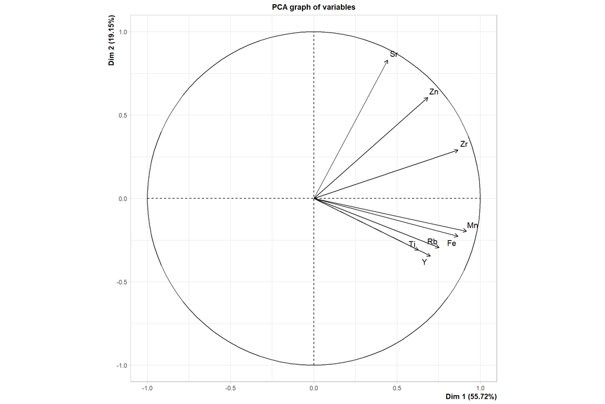

```
## **Results for the Principal Component Analysis (PCA)**
## The analysis was performed on 19 individuals, described by 8 variables
## *The results are available in the following objects:
##
##    name               description
## 1  "$eig"             "eigenvalues"
## 2  "$var"             "results for the variables"
## 3  "$var$coord"       "coord. for the variables"
## 4  "$var$cor"         "correlations variables - dimensions"
## 5  "$var$cos2"        "cos2 for the variables"
## 6  "$var$contrib"     "contributions of the variables"
## 7  "$ind"             "results for the individuals"
## 8  "$ind$coord"       "coord. for the individuals"
## 9  "$ind$cos2"        "cos2 for the individuals"
## 10 "$ind$contrib"     "contributions of the individuals"
## 11 "$call"            "summary statistics"
## 12 "$call$centre"     "mean of the variables"
## 13 "$call$ecart.type" "standard error of the variables"
## 14 "$call$row.w"      "weights for the individuals"
## 15 "$call$col.w"      "weights for the variables"
```

```r
PCA(pxrf_final[3:10])
```

#### pXRF: HCA

**HCA including only MB samples, colored by area**:

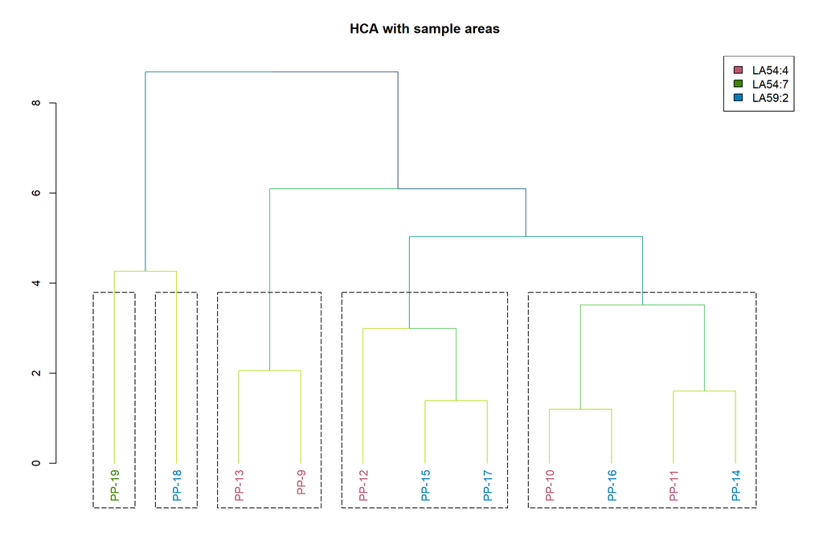

```r
# HCA dendrogram, samples color coded by area:
dend <-
    pxrf_MB %>%                         # data
    dist %>%                            # calculate a distance matrix
    hclust(method = "ward.D2") %>%      # hierarchical clustering
    as.dendrogram %>%                   # turn the object into a dendrogram
    highlight_branches_col
    area <- as.factor(pxrf_MB[, 1])
    n_area <- length(unique(area))
    cols_a <- colorspace::rainbow_hcl(n_area, c = 70, l  = 50)
    col_area <- cols_a[area]
    labels_colors(dend) <- col_area[order.dendrogram(dend)]

    plot(dend, main="HCA with sample areas")
    rect.dendrogram(dend, 5, border = "Black", lty = 5)
    legend("topright", legend = levels(area), fill = cols_a)
```

**HCA with soil samples, colored by type**:

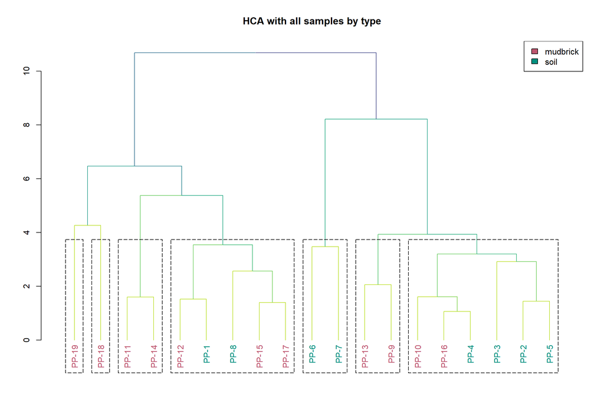

```r
# HCA dendrogram, samples color coded by type:
dend3 <-
    pxrf_final %>%                      # data
    dist %>%                            # calculate a distance matrix
    hclust(method = "ward.D2") %>%      # hierarchical clustering
    as.dendrogram %>%                   # turn the object into a dendrogram
    highlight_branches_col
    type <- as.factor(pxrf_final[, 2])
    n_type <- length(unique(type))
    cols_t <- colorspace::rainbow_hcl(n_type, c = 70, l  = 50)
    col_type <- cols_t[type]
    labels_colors(dend3) <- col_type[order.dendrogram(dend3)]

    plot(dend3, main="HCA with all samples by type")
    rect.dendrogram(dend3, 7, border = "Black", lty = 5)
    legend("topright", legend = levels(type), fill = cols_t)
```

### Grain size analysis

#### Data preparation

```r
# Libraries
library(dplyr);
library(openxlsx);
library(ggtern);
library(reshape2)

# Read and filter data
grain <- read.xlsx("data/grain_PP.xlsx", sep=";")

# Remove automatically created averages in order to include results from multiple runs for the same sample
grain <- grain %>%
  filter(!grepl('Average', Sample)) %>%
  filter(!grepl('test', Sample))

# Average data by "Sample", "Context" and "Type" columns from the original dataset
grain <- aggregate(grain, by=list(grain$Sample, grain$Context, grain$Type), FUN=mean)
```

[output not shown]

[output cut: 115 more lines]

[output not shown]

```r
# Remove the now empty columns for clarity
grain <- grain %>% select(-Sample)
grain <- grain %>% select(-Context)
grain <- grain %>% select(-Type)

# Assign sample names ("Group.1") as row names, and rename the other created columns back to "Type" and "Area" for clarity
rownames(grain) <- grain$Group.1
names(grain)[names(grain) == "Group.1"] <- "Sample"
names(grain)[names(grain) == "Group.2"] <- "Context"
names(grain)[names(grain) == "Group.3"] <- "Type"

# Scaling clay-silt-sand portions to values between 0 and 1
# (Otherwise the differences in low clay percentages are too small to differentiate)
normalize <- function(x, na.rm=TRUE){(x-min(x, na.rm=TRUE))/(max(x, na.rm=TRUE)-min(x, na.rm=TRUE))}

# Apply function "normalize" to clay, silt and sand columns
grain_01 <- as.data.frame(apply(grain[5:7], 2, normalize))
```

#### Ternary plots

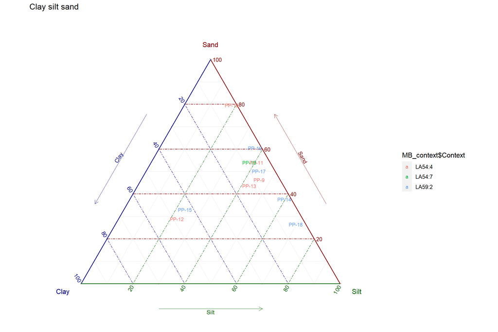

```r
# Creating subsets for only mudbricks
MB_grain <- grain_01[c(1:11),]
MB_context <- grain[c(1:11),]

# Ternary plots
ggtern(data=MB_grain, aes(x=Clay, y=Sand, z=Silt, color=MB_context$Context)) +
  labs(title="Clay silt sand") +
  theme_rgbw() +
  theme_nomask() +
  geom_point(size=0) +
  geom_text(aes(label=rownames(MB_grain)), size=3)
```

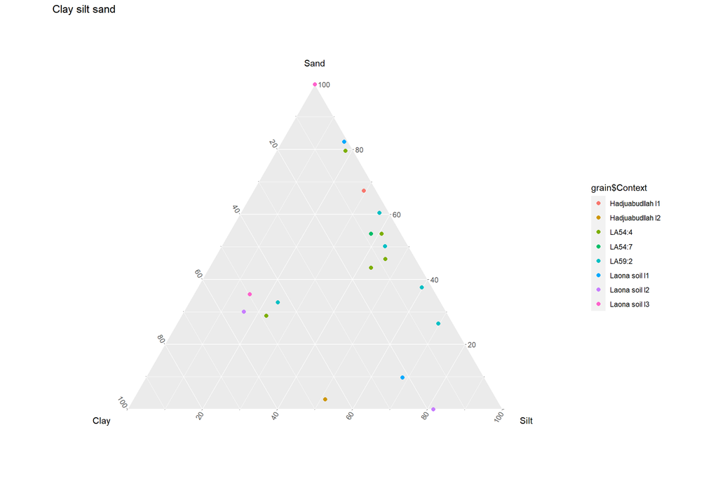

```r
ggtern(data=grain_01, aes(x=Clay, y=Sand, z=Silt, color=grain$Context)) +
  labs(title="Clay silt sand") +
  theme_nomask() +
  geom_mask() +
  geom_point(size=2)
```

#### Line plots

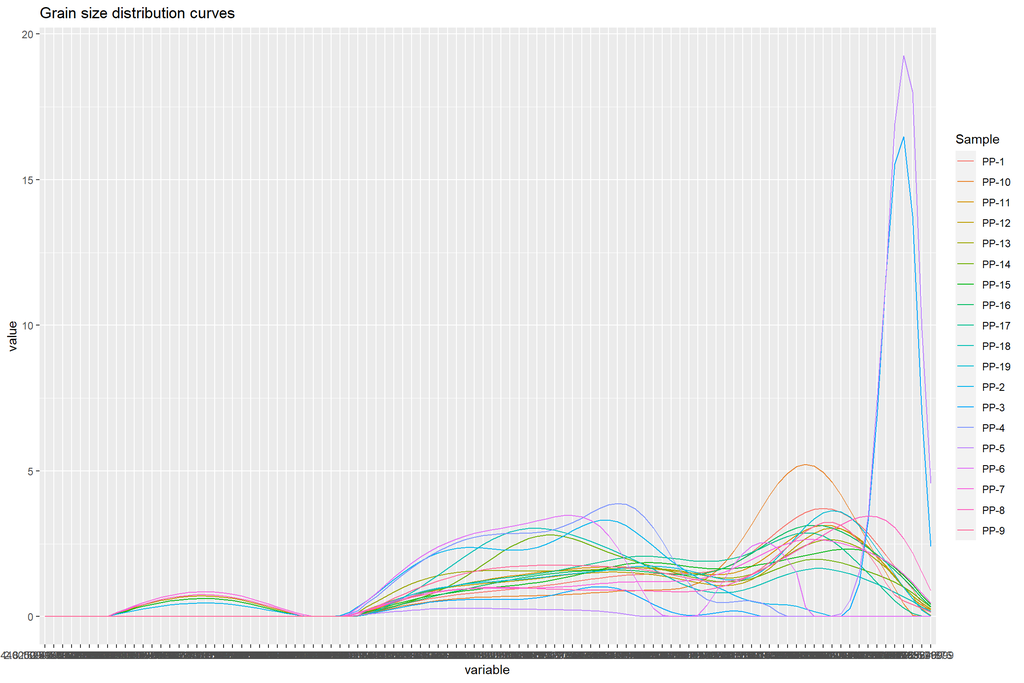

```r
# Reshaping data to long form
grain_long <- melt(grain[c(1,14:113)], id = "Sample")

ggplot(grain_long, aes(x=variable, y=value, color=Sample, group=Sample)) +
    geom_line() +
    ggtitle("Grain size distribution curves")
```

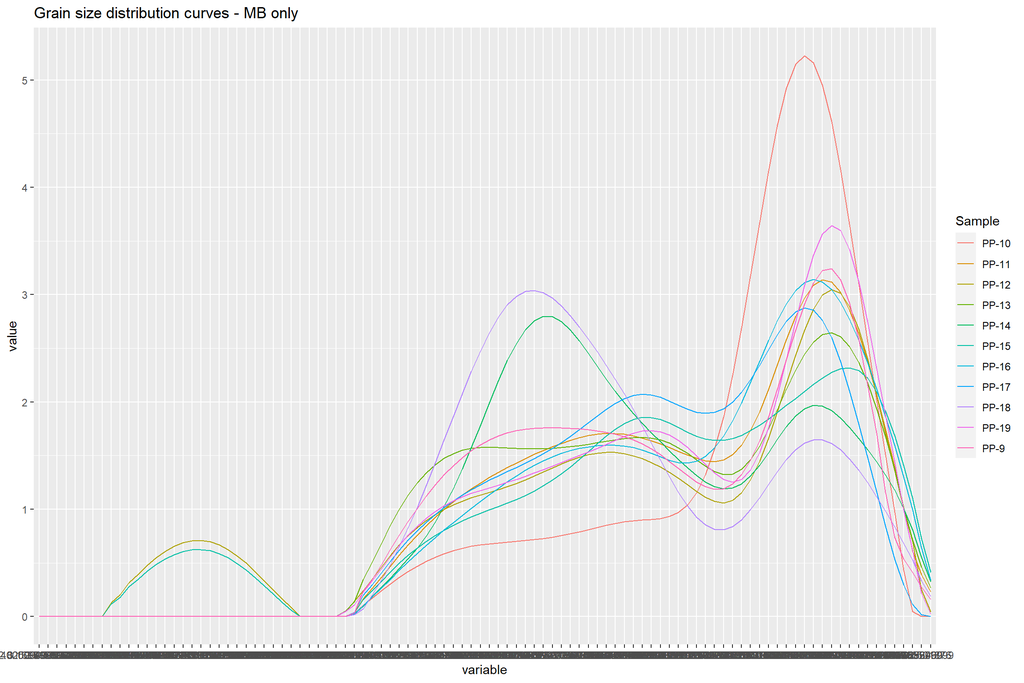

```r
# Only MB samples
grain_MB2 <- grain[c(1:11),]
grain_long3 <- melt(grain_MB2[c(1,14:113)], id = "Sample")

ggplot(grain_long3, aes(x=variable, y=value, color=Sample, group=Sample)) +
    geom_line() +
    ggtitle("Grain size distribution curves - MB only")
```

**Barplots for 5 size fractions**:

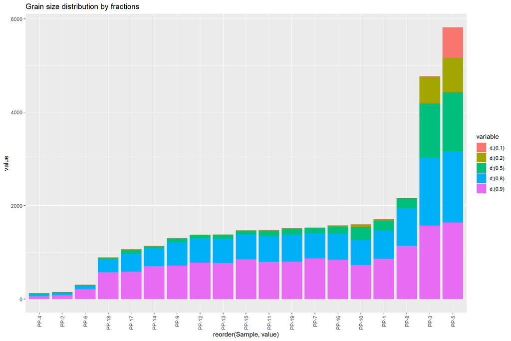

```r
# Stacked barplot
grain_long2 <- melt(grain[c(1,9:13)], id = "Sample")

ggplot(grain_long2, aes(x = reorder(Sample, value), y = value, fill = variable)) +
  geom_bar(stat = 'identity', position = 'stack') +
    theme(axis.text.x = element_text(angle = 90, vjust = 0.5, hjust=1)) +
    ggtitle("Grain size distribution by fractions")
```

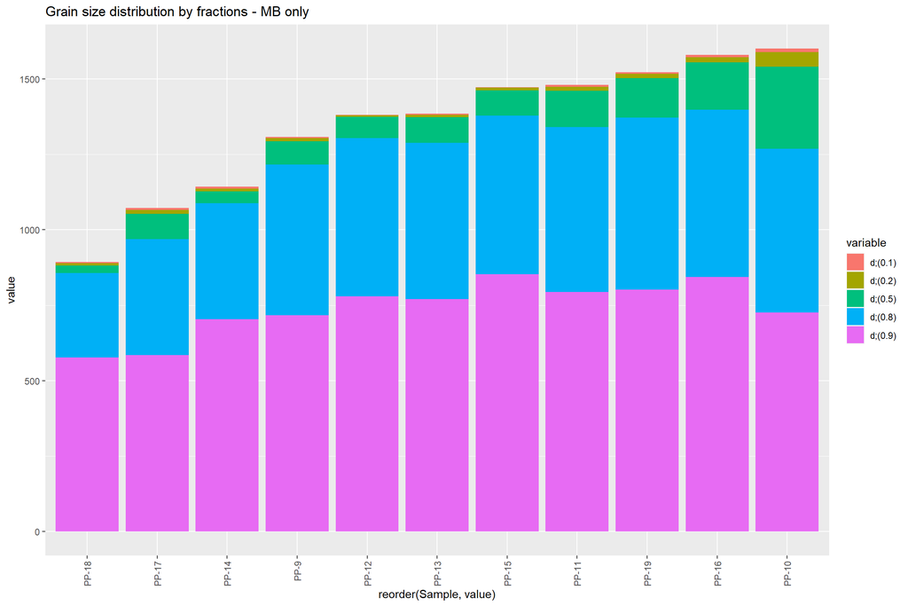

```r
# Stacked barplot
grain_long4 <- melt(grain_MB2[c(1,9:13)], id = "Sample")

ggplot(grain_long4, aes(x = reorder(Sample, value), y = value, fill = variable)) +
  geom_bar(stat = 'identity', position = 'stack') +
    theme(axis.text.x = element_text(angle = 90, vjust = 0.5, hjust=1)) +
    ggtitle("Grain size distribution by fractions - MB only")
```

### Loss on ignition

We did loss on ignition analysis both in the traditional manual method and with a modern TGA for comparison.

#### Data preparation

```r
# Libraries
library(openxlsx);
library(dplyr);
library(ggplot2);
library(ggrepel); # Preventing labels from overlapping
library(reshape2) # Melt-function for reshaping data to long form

loi <- read.xlsx("data/loi_PP.xlsx", sep=";")
tga <- read.xlsx("data/tga_PP.xlsx", sep=";")

# Remove rows containing words 'kekkila' (internal standard)
tga <- filter(tga, !grepl('kekkila', Name))

# TGA character columns to numeric
tga[, c(4:7)] <- sapply(tga[, c(4:7)], as.numeric)

# Sample names as rownames
rownames(loi) <- loi$sample
rownames(tga) <- tga$Name

# Creating new columns for analysis by subtracting crucible mass;
# "dry" (mass after drying), "c550" (mass after 550 C), "c950" (mass after 950 C)
loi$dry <- (loi$dry_weight - loi$crucible)
loi$c550mass <- (loi$after_550_C - loi$crucible)
loi$c950mass <- (loi$after_950_C - loi$crucible)

loi$c550 <- (loi$dry - loi$c550mass)/(loi$dry) * 100
loi$c950 <- (loi$c550mass - loi$c950mass)/(loi$c550mass) * 100

# Same with TGA
tga$c550 <- (tga$Dry - tga$Mass_550)/(tga$Dry) * 100
tga$c950 <- (tga$Mass_550 - tga$Mass_950)/(tga$Mass_550) * 100

# Creating MB only subsets
loi_MB <- subset(loi[9:19, ])

tga_MB <- subset(tga[9:20, ])
tga_MB <- subset(tga_MB[-4, ]) # No duplicates

tga_MB1 <- subset(tga[9:22, ]) # Includes some duplicates

# Transforming data to long form (MB only)
loi_MB_long <- loi_MB[c(8,13:14)]
loi_MB_long <- melt(loi_MB_long, id = "context")

tga_MB_long <- tga_MB1[c(8,10:11)]
tga_MB_long <- melt(tga_MB_long, id = "context")

# Transforming data to long form (Soil included)
loi_long <- loi[c(8,13:14)]
loi_long <- melt(loi_long, id = "context")

tga_long <- tga[c(8,10:11)]
tga_long <- melt(tga_long, id = "context")

# Long form data for stacked barplots
loi_long2 <- melt(loi_MB[c(1,13:14)], value.name = "Temp", id= "sample")

tga_long2 <- melt(tga_MB[c(1,10:11)], value.name = "Temp", id= "Name")
```

**LOI dataset**:

```r
loi[c(8:9,13:14)]
```

```
##                 context         type     c550     c950
## PP-1   Hadjuabudllah l1 soil layer 1 5.986894 19.67880
## PP-2   Hadjuabudllah l2 soil layer 2 4.466405 17.59870
## PP-3      Laona soil l1 soil layer 1 5.734589 21.55943
## PP-4      Laona soil l2 soil layer 2 4.323061 17.76702
## PP-5      Laona soil l3 soil layer 3 6.877261 19.61697
## PP-6      Laona soil l1 soil layer 1 5.038672 17.28507
## PP-7      Laona soil l2 soil layer 2 5.582797 17.71488
## PP-8      Laona soil l3 soil layer 3 5.134295 19.63221
## PP-9             LA54:4     mudbrick 7.451505 18.35791
## PP-10            LA54:4     mudbrick 3.557623 14.55842
## PP-11            LA54:4     mudbrick 4.002255 21.24757
## PP-12            LA54:4     mudbrick 2.797378 22.23702
## PP-13            LA54:4     mudbrick 3.156025 21.81049
## PP-14            LA59:2     mudbrick 2.818483 22.65698
## PP-15            LA59:2     mudbrick 3.822946 25.15246
## PP-16            LA59:2     mudbrick 2.365256 21.25664
## PP-17            LA59:2     mudbrick 3.860836 20.58203
## PP-18            LA59:2     mudbrick 2.451871 33.21076
## PP-19            LA54:7     mudbrick 1.739797 33.78112
## PP-1_2 Hadjuabudllah l1 soil layer 1 6.137732 21.18259
## PP-2_2 Hadjuabudllah l2 soil layer 2 4.429557 18.22193
## PP-3_2    Laona soil l1 soil layer 1 5.521160 22.61670
## PP-4_2    Laona soil l2 soil layer 2 4.582459 20.95611
## PP-5_2    Laona soil l3 soil layer 3 6.888629 20.42575
## PP-6_2    Laona soil l1 soil layer 1 5.348806 16.70897
## PP-7_2    Laona soil l2 soil layer 2 5.537857 18.92266
## PP-8_2    Laona soil l3 soil layer 3 5.230428 19.99844
```

**TGA dataset**:

```r
tga[c(8:9,10:11)]
```

```
##                    context         type     c550     c950
## PP-1      Hadjuabudllah l1 soil layer 1 5.328983 22.05629
## PP-2      Hadjuabudllah l2 soil layer 2 3.798409 18.86880
## PP-3         Laona soil l1 soil layer 1 4.452588 21.57446
## PP-4         Laona soil l2 soil layer 2 4.537622 20.07908
## PP-5         Laona soil l3 soil layer 3 4.657919 23.10036
## PP-6         Laona soil l1 soil layer 1 4.892221 16.89988
## PP-7         Laona soil l2 soil layer 2 4.601116 18.47942
## PP-8         Laona soil l3 soil layer 3 4.525488 20.99294
## PP-9                LA54:4     mudbrick 5.392111 18.62861
## PP-10               LA54:4     mudbrick 2.360845 15.24474
## PP-11               LA54:4     mudbrick 2.773246 24.52314
## PP-11 (2)           LA54:4     mudbrick 3.164817 20.66002
## PP-12               LA54:4     mudbrick 2.734021 21.45383
## PP-13               LA54:4     mudbrick 3.235943 21.34319
## PP-14               LA59:2     mudbrick 3.202329 22.49060
## PP-15               LA59:2     mudbrick 3.508931 22.92802
## PP-16               LA59:2     mudbrick 2.215719 19.75916
## PP-17               LA59:2     mudbrick 3.921377 22.16794
## PP-18               LA59:2     mudbrick 3.234501 31.05334
## PP-19               LA54:7     mudbrick 2.204428 33.79251
## PP-10 (2)           LA54:4     mudbrick 2.226568 14.54839
## PP-9 (2)            LA54:4     mudbrick 5.258741 19.01388
## PP-8 (2)     Laona soil l3 soil layer 3 4.474886 22.50903
## PP-7 (2)     Laona soil l3 soil layer 2 4.739991 19.00483
## PP-6 (2)     Laona soil l1 soil layer 1 4.618851 18.27756
## PP-5 (2)     Laona soil l3 soil layer 3 5.122344 22.59504
## PP-4 (2)     Laona soil l2 soil layer 2 4.559860 20.33749
## PP-3 (2)     Laona soil l1 soil layer 1 4.302926 20.35644
```

#### Boxplots

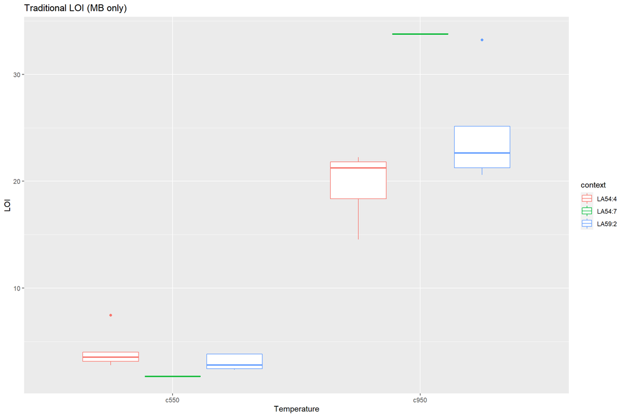

```r
# Colored boxplots: Trad LOI, MB only
ggplot(loi_MB_long, aes(x = variable, y = value, color = context)) +
  geom_boxplot() +
  labs(title="Traditional LOI (MB only)",
        x ="Temperature", y = "LOI")
```

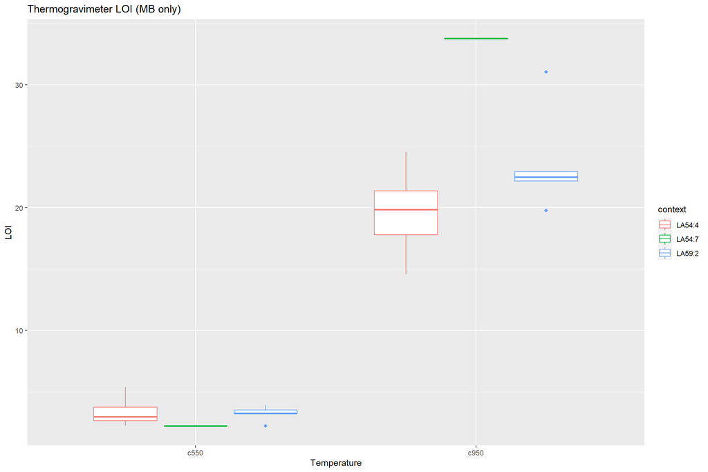

```r
# Colored boxplots: TGA LOI, MB only
ggplot(tga_MB_long, aes(x = variable, y = value, color = context)) +
  geom_boxplot() +
  labs(title="Thermogravimeter LOI (MB only)",
        x ="Temperature", y = "LOI")
```

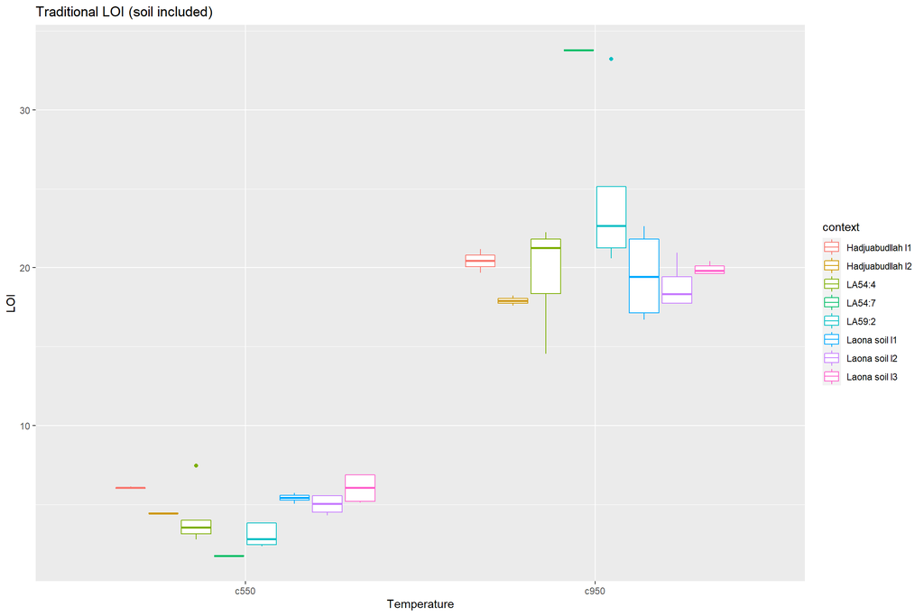

```r
# Colored boxplots: Trad LOI, soil samples included
ggplot(loi_long, aes(x = variable, y = value, color = context)) +
  geom_boxplot() +
  labs(title="Traditional LOI (soil included)",
        x ="Temperature", y = "LOI")
```

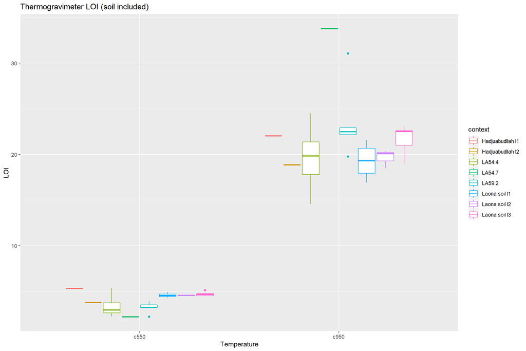

```r
# Colored boxplots: TGA LOI, soil samples included
ggplot(tga_long, aes(x = variable, y = value, color = context)) +
  geom_boxplot() +
  labs(title="Thermogravimeter LOI (soil included)",
        x ="Temperature", y = "LOI")
```

#### Biplots

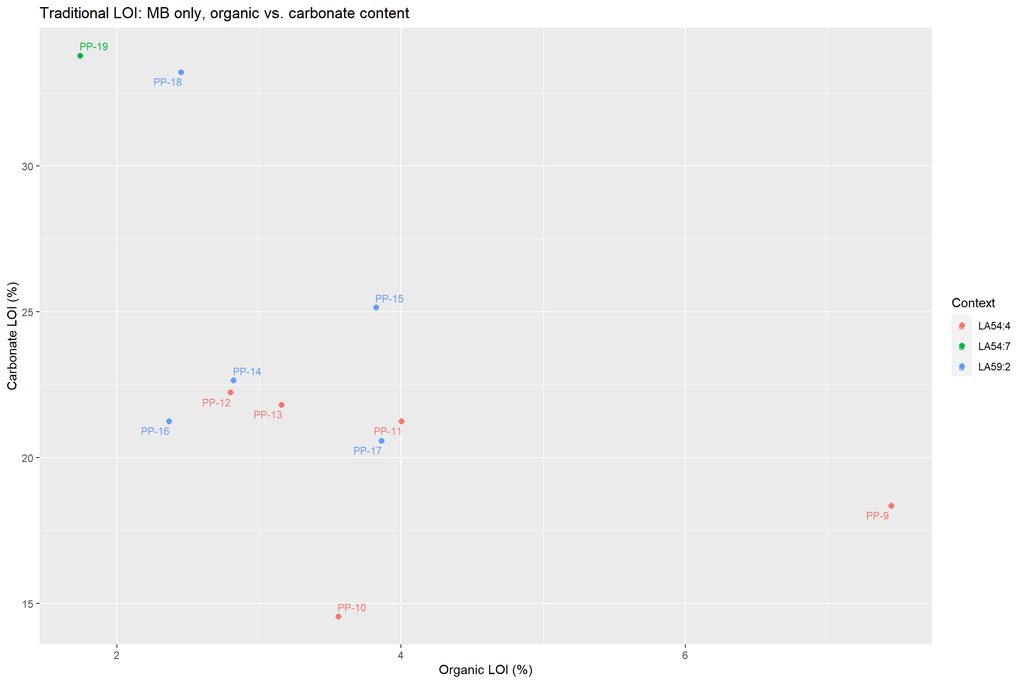

```r
# MB only biplot: Trad LOI
ggplot(loi_MB,
      aes(c550, c950, label = rownames(loi_MB), color = factor(context))) +
      geom_point(size=2) +
      geom_text_repel(size=3) +
      labs(title = "Traditional LOI: MB only, organic vs. carbonate content",
           color = "Context",
           x = "Organic LOI (%)",
           y = "Carbonate LOI (%)") +
      theme(axis.title = element_text())
```

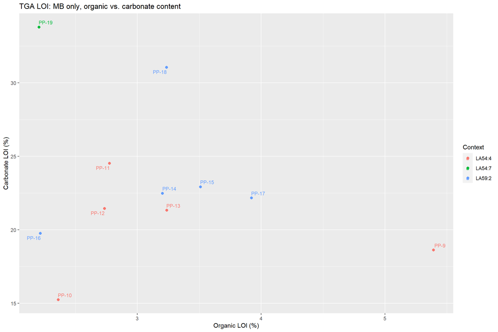

```r
# MB only biplot: TGA LOI
ggplot(tga_MB,
      aes(c550, c950, label = rownames(tga_MB), colour = factor(context))) +
      geom_point(size=2) +
      geom_text_repel(size=3) +
      labs(title = "TGA LOI: MB only, organic vs. carbonate content",
           color = "Context",
           x = "Organic LOI (%)",
           y = "Carbonate LOI (%)") +
      theme(axis.title = element_text())
```

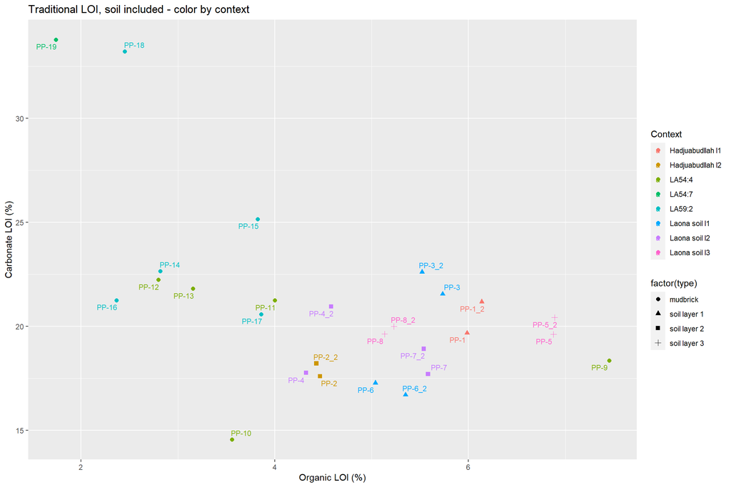

```r
# Color by context biplot: Trad LOI
ggplot(loi,
      aes(c550, c950, label = rownames(loi), colour = factor(context))) +
      geom_point(size=2, aes(shape = factor(type))) +
      geom_text_repel(size=3) +
      labs(title = "Traditional LOI, soil included - color by context",
           color = "Context",
           x = "Organic LOI (%)",
           y = "Carbonate LOI (%)") +
      theme(axis.title = element_text())
```

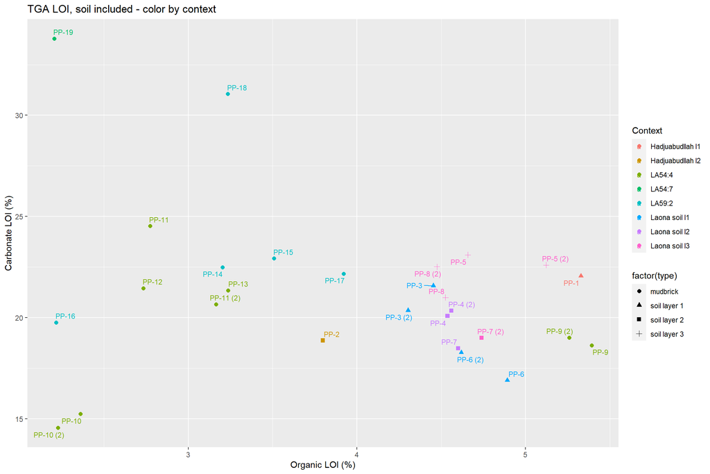

```r
# Color by context biplot: TGA
ggplot(tga,
      aes(c550, c950, label = rownames(tga), colour = factor(context))) +
      geom_point(size=2, aes(shape = factor(type))) +
      geom_text_repel(size=3) +
      labs(title = "TGA LOI, soil included - color by context",
           color = "Context",
           x = "Organic LOI (%)",
           y = "Carbonate LOI (%)") +
      theme(axis.title = element_text())
```

#### Stacked barplots

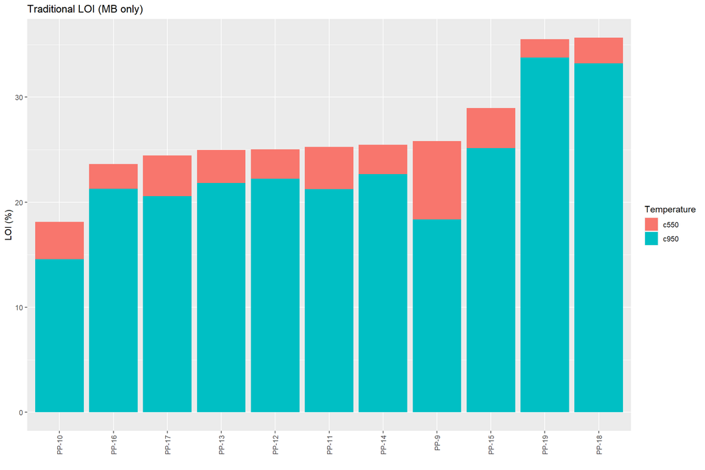

```r
# Trad LOI stacked barplot
ggplot(loi_long2, aes(x = reorder(sample, Temp), y = Temp, fill = variable)) +
  geom_bar(stat = 'identity', position = 'stack') +
    theme(axis.text.x = element_text(angle = 90, vjust = 0.5, hjust=1)) +
    labs(title="Traditional LOI (MB only)",
         fill="Temperature",
         x = "",
         y = "LOI (%)")
```

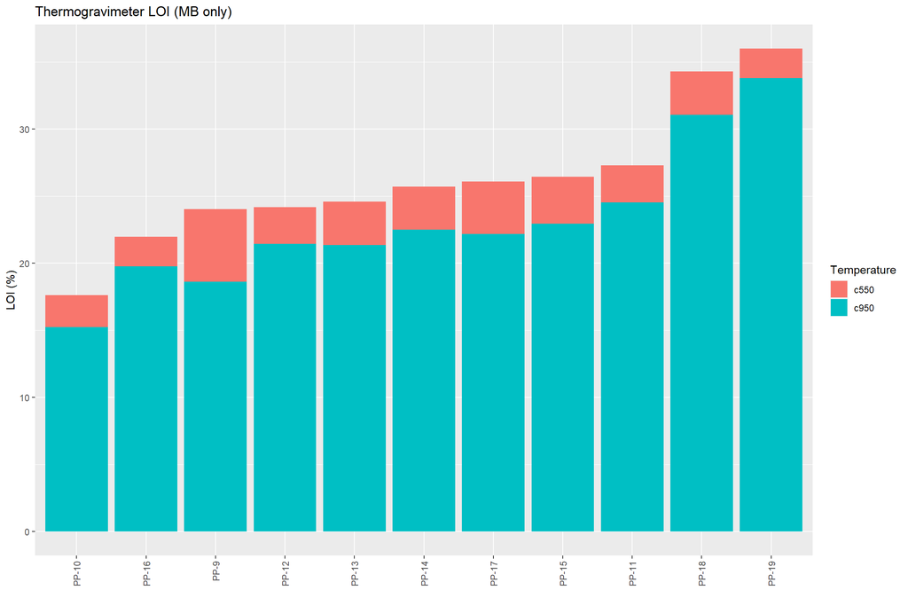

```r
# TGA LOI stacked barplot
ggplot(tga_long2, aes(x = reorder(Name, Temp), y = Temp, fill = variable)) +
  geom_bar(stat = 'identity', position = 'stack') +
    theme(axis.text.x = element_text(angle = 90, vjust = 0.5, hjust=1)) +
    labs(title="Thermogravimeter LOI (MB only)",
         fill="Temperature",
         x = "",
         y = "LOI (%)")
```

### Colorimetry

```r
# Libraries
library(dplyr);
library(ggplot2);
library(ggrepel);
library(rgl);
library(plot3D);
library(colordistance)

color1 <- read.table("data/color_PP.txt", header = TRUE, sep = "\t", dec = ",")
rownames(color1) <- color1$Data.Name
color <- subset(color1[, 3:5])
summary(color)
```

```
##        L               a               b
##  Min.   :62.38   Min.   : 7.27   Min.   :19.90
##  1st Qu.:63.47   1st Qu.: 8.50   1st Qu.:21.36
##  Median :64.19   Median : 9.34   Median :21.72
##  Mean   :65.50   Mean   : 9.29   Mean   :21.92
##  3rd Qu.:65.78   3rd Qu.:10.56   3rd Qu.:22.96
##  Max.   :72.00   Max.   :10.90   Max.   :23.90
```

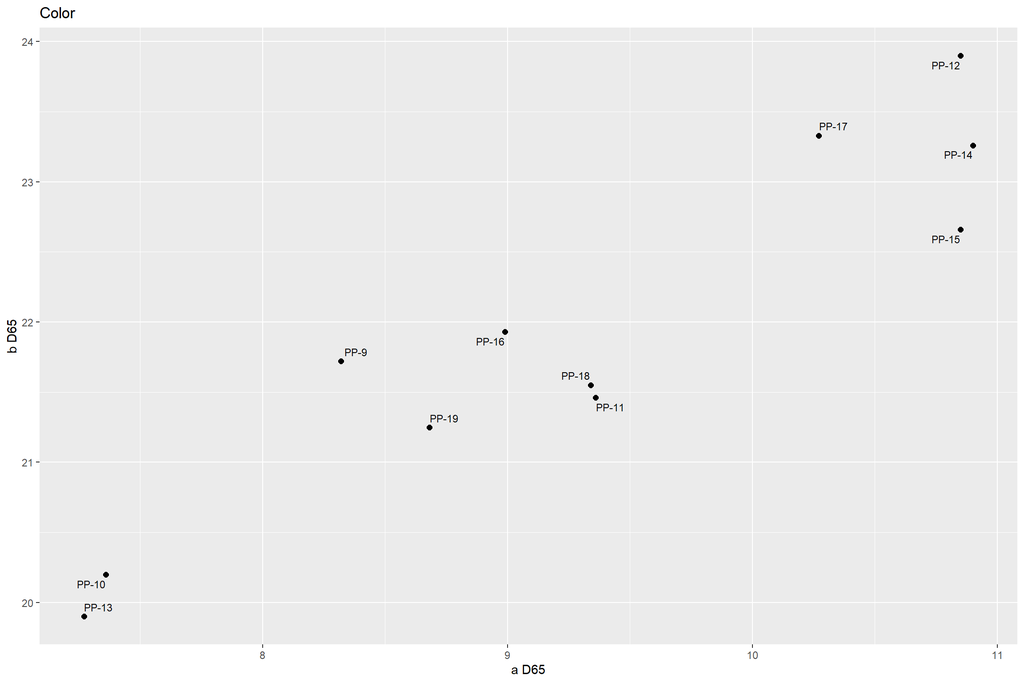

```r
ggplot(color,
      aes(a, b, label = rownames(color))) +
      geom_point(size=2) +
      geom_text_repel(size=3) +
      labs(title = "Color") +
      xlab("a D65") +
      ylab("b D65")
```

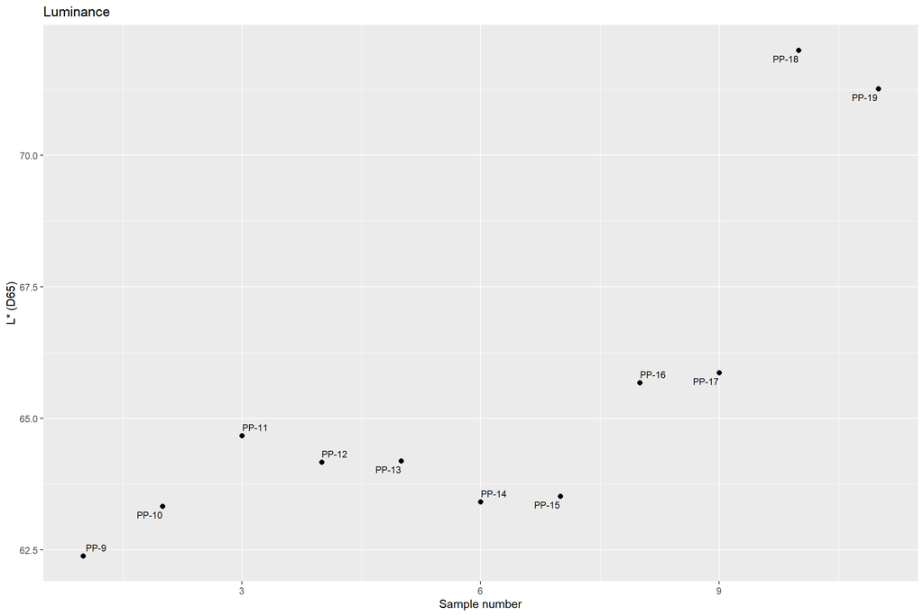

```r
ggplot(color1,
      aes(X, L, label = rownames(color))) +
      geom_point(size=2) +
      geom_text_repel(size=3) +
      labs(title = "Luminance") +
      ylab("L* (D65)") +
      xlab("Sample number")
```

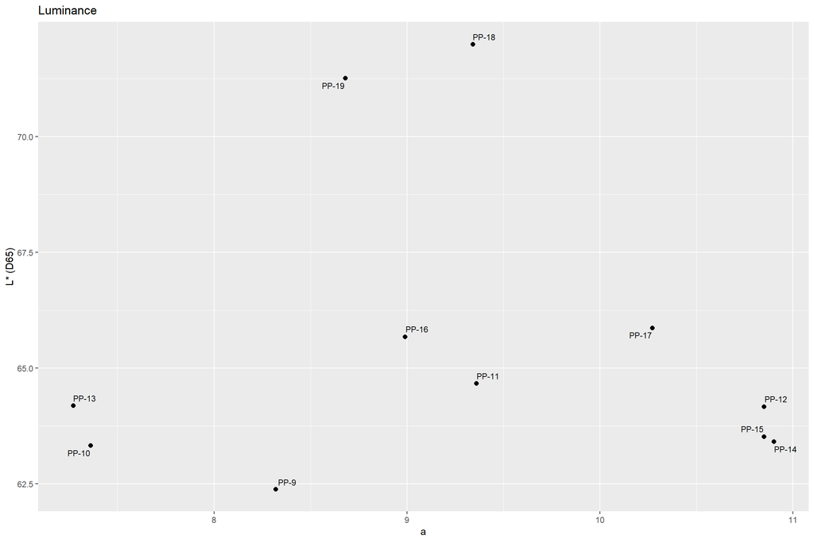

```r
ggplot(color,
      aes(a, L, label = rownames(color))) +
      geom_point(size=2) +
      geom_text_repel(size=3) +
      labs(title = "Luminance") +
      ylab("L* (D65)") +
      xlab("a")
```